# Qualitative Activity Recognition using Random Forest Prediction Model

Juan Carlos Lagomacini

20 de agosto de 2015

### Summary

In this report a qualitative activity recognition of Weight Lifting Exercises is performed. From a large data set with observations from accelerometers installed on the belt, arm, and dumbell of 6 participants, a random forest is used to predict the classe of activity achieved for each participant at different moments when performing Unilateral Dumbbell Biceps Curl. This predictive model is used in a final test set to predict the class of the activity for each 20 observations of a specific user.

### Dataset

The training and test data are available here:

https://d396qusza40orc.cloudfront.net/predmachlearn/pml-training.csv https://d396qusza40orc.cloudfront.net/predmachlearn/pml-testing.csv

Both data set consist of 160 different variables corresponding to exercise features. Information about the variables in the dataset can be find [here](http://groupware.les.inf.puc-rio.br/har).

In the training set, the variable *classe* corresponds to the to the type of activity corresponding to a certain observation. This will be the variable to predict in the test set. Class A corresponds to an activity according to the specifications of the exercise; class B throwing the elbows to the front; class C lifting the dumbbell only halfway; class D lowering the dumbbell only halfway; and class E throwing the hips to the front. Here, the structure of the first 10 variables and the last one in the *training* and *testing* data is summarised:

TRAINING SET:

```
##        X            user_name    raw_timestamp_part_1 raw_timestamp_part_2
##  Min.   :    1   adelmo  :3892   Min.   :1.322e+09    Min.   :   294
##  1st Qu.: 4906   carlitos:3112   1st Qu.:1.323e+09    1st Qu.:252912
##  Median : 9812   charles :3536   Median :1.323e+09    Median :496380
##  Mean   : 9812   eurico  :3070   Mean   :1.323e+09    Mean   :500656
##  3rd Qu.:14717   jeremy  :3402   3rd Qu.:1.323e+09    3rd Qu.:751891
##  Max.   :19622   pedro   :2610   Max.   :1.323e+09    Max.   :998801
##
##           cvtd_timestamp  new_window    num_window      roll_belt
##  28/11/2011 14:14: 1498   no :19216   Min.   :  1.0   Min.   :-28.90
##  05/12/2011 11:24: 1497   yes:  406   1st Qu.:222.0   1st Qu.:  1.10
##  30/11/2011 17:11: 1440               Median :424.0   Median :113.00
##  05/12/2011 11:25: 1425               Mean   :430.6   Mean   : 64.41
##  02/12/2011 14:57: 1380               3rd Qu.:644.0   3rd Qu.:123.00
##  02/12/2011 13:34: 1375               Max.   :864.0   Max.   :162.00
##  (Other)         :11007
##    pitch_belt          yaw_belt       total_accel_belt kurtosis_roll_belt
##  Min.   :-55.8000   Min.   :-180.00   Min.   : 0.00             :19216
##  1st Qu.:  1.7600   1st Qu.: -88.30   1st Qu.: 3.00    #DIV/0!  :   10
##  Median :  5.2800   Median : -13.00   Median :17.00    -1.908453:    2
##  Mean   :  0.3053   Mean   : -11.21   Mean   :11.31    -0.016850:    1
##  3rd Qu.: 14.9000   3rd Qu.:  12.90   3rd Qu.:18.00    -0.021024:    1
##  Max.   : 60.3000   Max.   : 179.00   Max.   :29.00    -0.025513:    1
##                                                        (Other)  :  391
##  kurtosis_picth_belt kurtosis_yaw_belt skewness_roll_belt classe
##           :19216            :19216              :19216    A:5580
##  #DIV/0!  :   32     #DIV/0!:  406     #DIV/0!  :    9    B:3797
##  47.000000:    4                       0.000000 :    4    C:3422
##  -0.150950:    3                       0.422463 :    2    D:3216
##  -0.684748:    3                       -0.003095:    1    E:3607
##  -1.750749:    3                       -0.010002:    1
##  (Other)  :  361                       (Other)  :  389
```

TESTING SET:

```
##        X            user_name raw_timestamp_part_1 raw_timestamp_part_2
##  Min.   : 1.00   adelmo  :1   Min.   :1.322e+09    Min.   : 36553
##  1st Qu.: 5.75   carlitos:3   1st Qu.:1.323e+09    1st Qu.:268655
##  Median :10.50   charles :1   Median :1.323e+09    Median :530706
##  Mean   :10.50   eurico  :4   Mean   :1.323e+09    Mean   :512167
##  3rd Qu.:15.25   jeremy  :8   3rd Qu.:1.323e+09    3rd Qu.:787738
##  Max.   :20.00   pedro   :3   Max.   :1.323e+09    Max.   :920315
##
##           cvtd_timestamp new_window   num_window      roll_belt
##  30/11/2011 17:11:4      no:20      Min.   : 48.0   Min.   : -5.9200
##  05/12/2011 11:24:3                 1st Qu.:250.0   1st Qu.:  0.9075
##  30/11/2011 17:12:3                 Median :384.5   Median :  1.1100
##  05/12/2011 14:23:2                 Mean   :379.6   Mean   : 31.3055
##  28/11/2011 14:14:2                 3rd Qu.:467.0   3rd Qu.: 32.5050
##  02/12/2011 13:33:1                 Max.   :859.0   Max.   :129.0000
##  (Other)         :5
##    pitch_belt         yaw_belt      total_accel_belt kurtosis_roll_belt
##  Min.   :-41.600   Min.   :-93.70   Min.   : 2.00    Mode:logical
##  1st Qu.:  3.013   1st Qu.:-88.62   1st Qu.: 3.00    NA's:20
##  Median :  4.655   Median :-87.85   Median : 4.00
##  Mean   :  5.824   Mean   :-59.30   Mean   : 7.55
##  3rd Qu.:  6.135   3rd Qu.:-63.50   3rd Qu.: 8.00
##  Max.   : 27.800   Max.   :162.00   Max.   :21.00
##
##  kurtosis_picth_belt kurtosis_yaw_belt skewness_roll_belt   problem_id
##  Mode:logical        Mode:logical      Mode:logical       Min.   : 1.00
##  NA's:20             NA's:20           NA's:20            1st Qu.: 5.75
##                                                           Median :10.50
##                                                           Mean   :10.50
##                                                           3rd Qu.:15.25
##                                                           Max.   :20.00
##
```

Looking to the testing set the first 7 and *problem_id* variables correspond to meaningless variables to use for predictions. Moreover, looking through the whole testing dataset, there are different variables (columns) with only NAs. Therefore all those variables were not considered from the training set. In total only 60 are considered.

According to the variable *“new_window”* the observations corresponding to “yes” were remove from the training dataset, since they are not present in the testing set. These observations in the training dataset summarise the statistics of the features.

### Finding correlations

Using the functions *nearZeroVar*, *findCorrelation* and *findLinearCombos* from the caret package the variability from the remaining dataset, the correlations between columns and the combinations between rows were estimated. No linear combinations between rows and zero variability in the variables were found. However, a correlation of 90% (cut.off = 0.9) were found in the following variables and then were drop off from the training set too:

```
## [1] "accel_belt_z"     "roll_belt"        "accel_belt_y"
## [4] "accel_belt_x"     "gyros_dumbbell_x" "gyros_dumbbell_z"
## [7] "gyros_arm_x"
```

Summarising, a training data frame of 19216 and 46 variables was used for the prediction model.

```r
dim(df[-c(1:7,ind)])
```

```
## [1] 19216    46
```

### Plotting

Using the *featurePlot* function from *caret* package, a plot of variables were used to see some correlation between them. The following plot shows three variables to better see some relationship between variables.

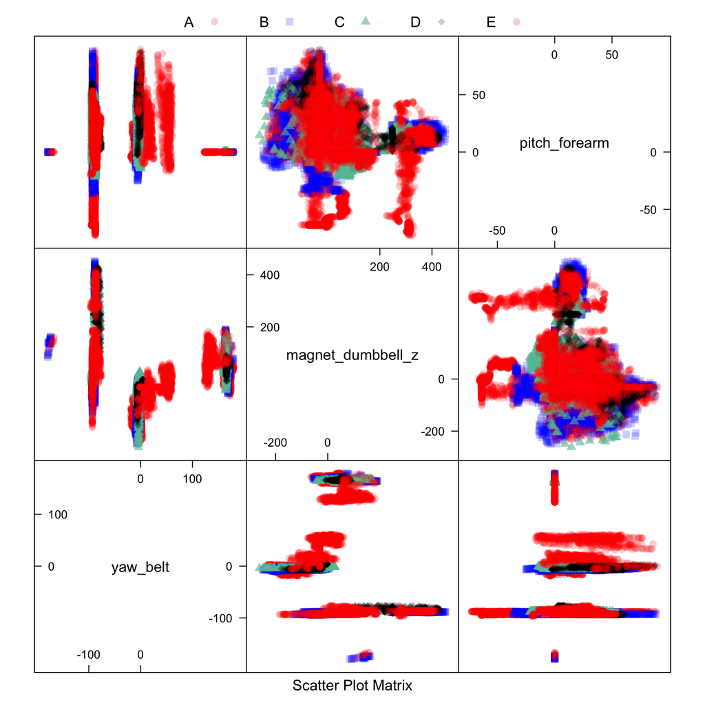

It is observed some independent regions in the plot. It indicates that a clasification algorithm it is possible using the training set. Let see also a density plot of those variables:

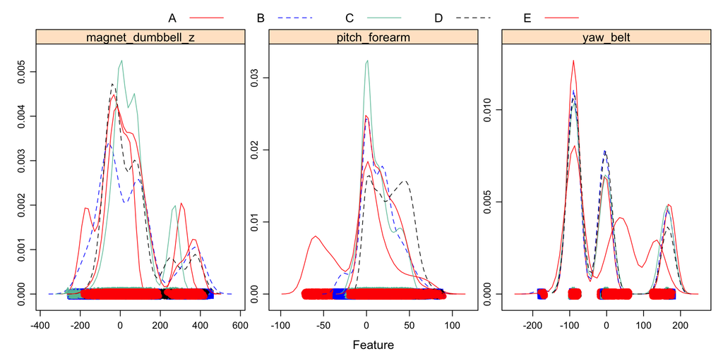

### Prediction model for classe variable

Although it is not necessary for random forest algorithm to perform *cross validation*, a 70% of the training dataset was used for the training and 30% for testing using the *createDataPartition* function (caret). A *K-fold Cross validation* is not necessary for such a large dataset.

```
## Random Forest
##
## 13453 samples
##    45 predictor
##     5 classes: 'A', 'B', 'C', 'D', 'E'
##
## No pre-processing
## Resampling: Bootstrapped (5 reps)
## Summary of sample sizes: 13453, 13453, 13453, 13453, 13453
## Resampling results
##
##   Accuracy   Kappa      Accuracy SD  Kappa SD
##   0.9804418  0.9752592  0.002263309  0.002836787
##
## Tuning parameter 'mtry' was held constant at a value of 10
##
```

| user | system | elapsed |
| --- | --- | --- |
| 96.080 | 10.708 | 63.100 |

The following results show the summary of cross validation for the 30% testing set showing a 99% of accuracy:

```
## Confusion Matrix and Statistics
##
##           Reference
## Prediction    A    B    C    D    E
##          A 1636   12    0    2    1
##          B    2 1097    6    0    0
##          C    0    5  993    8    2
##          D    2    1    6  934    7
##          E    1    0    0    0 1048
##
## Overall Statistics
##
##                Accuracy : 0.9905
##                  95% CI : (0.9876, 0.9928)
##     No Information Rate : 0.2847
##     P-Value [Acc > NIR] : < 2.2e-16
##
##                   Kappa : 0.9879
##  Mcnemar's Test P-Value : NA
##
## Statistics by Class:
##
##                      Class: A Class: B Class: C Class: D Class: E
## Sensitivity            0.9970   0.9839   0.9881   0.9894   0.9905
## Specificity            0.9964   0.9983   0.9968   0.9967   0.9998
## Pos Pred Value         0.9909   0.9928   0.9851   0.9832   0.9990
## Neg Pred Value         0.9988   0.9961   0.9975   0.9979   0.9979
## Prevalence             0.2847   0.1935   0.1744   0.1638   0.1836
## Detection Rate         0.2839   0.1904   0.1723   0.1621   0.1818
## Detection Prevalence   0.2865   0.1917   0.1749   0.1648   0.1820
## Balanced Accuracy      0.9967   0.9911   0.9925   0.9930   0.9952
```

### Prediction for testing dataset.

The previous *Random Forest* model was used for activity recognition of 20 observations, each belonging to a specific user with a given features. These are the results:

```
##        User prediction
## 1     pedro          B
## 2    jeremy          A
## 3    jeremy          B
## 4    adelmo          A
## 5    eurico          A
## 6    jeremy          E
## 7    jeremy          D
## 8    jeremy          B
## 9  carlitos          A
## 10  charles          A
## 11 carlitos          B
## 12   jeremy          C
## 13   eurico          B
## 14   jeremy          A
## 15   jeremy          E
## 16   eurico          E
## 17    pedro          A
## 18 carlitos          B
## 19    pedro          B
## 20   eurico          B
```